# Return Home

[View Code on Github](https://github.com/JohnKimaiyo/Data-Analysis-Projects/blob/main/Python/Youtube%20Data%20API/Top%20Clothing%20Brands%20YouTube%20Channel%20Views%20Stats.ipynb)

# Top Clothing Brands YouTube Channel Views Stats

## 1 Louis Vuitton

Official International Website - Explore the World of Louis Vuitton, read our latest News, discover our Women and Men Collections

## 2 Chanel

Enter the world of CHANEL and discover the latest in Fashion & Accessories, Eyewear, Fragrance & Beauty, Fine Jewelry & Watches.

## 3 Gucci

Guccio Gucci S.p.A., doing business as Gucci, is an Italian luxury fashion house based in Florence, Italy. Its product lines include handbags, ready-to-wear, footwear, accessories, and home decoration; and it licenses its name and branding to Coty for fragrance and cosmetics under the name Gucci Beauty.

## 4 Hermès

Hermès International S.A. is a French luxury design house established on June 15th 1837. It specializes in leather goods, lifestyle accessories, home furnishings, perfumery, jewelry, watches and ready-to-wear. Since the 1950s, its logo has been a depiction of a ducal horse-drawn carriage

## 5 Christian Dior

Christian Dior SE, commonly known as Dior, is a French multinational luxury fashion house controlled and chaired by French businessman Bernard Arnault, who also heads LVMH. Dior holds 42.36% shares and 59.01% of voting rights within LVMH

```python
# lets import libraries
from googleapiclient.discovery import build
import pandas as pd
import seaborn as sn
```

## 1 Louis Vuitton

```python
# Function to get channel statistics
api_key = 'AIzaSyB24Kop04L1GlTgRCm1XtQ4KB2a4gaBOwA'
Louis_Vuitton_channel_id = ['UC5q0PIKGr2lGOsiT14AlEYg' # Louis Vuitton

              ]
youtube = build('youtube','v3',developerKey = api_key)

from googleapiclient.errors import HttpError

def get_channel_stats(youtube, Louis_Vuitton_channel_id):
    all_data = []
    try:
        request = youtube.channels().list(
            part='snippet,contentDetails,statistics',
            id=','.join(Louis_Vuitton_channel_id)
        )
        response = request.execute()

        for item in response.get('items', []):
            snippet = item.get('snippet', {})
            statistics = item.get('statistics', {})

            data = {
                'Channel_name': snippet.get('title', ''),
                'Subscribers': statistics.get('subscriberCount', ''),
                'Views': statistics.get('viewCount', ''),
                'Total_videos': statistics.get('videoCount', '')
            }

            all_data.append(data)

    except HttpError as e:
        print(f"HTTP error occurred: {e}")
        print(f"Request URL: {e.resp.request.url}")
        print(f"Request body: {e.resp.request.body}")

    return all_data
```

```python
get_channel_stats(youtube,Louis_Vuitton_channel_id)
```

```
[{'Channel_name': 'Louis Vuitton',
  'Subscribers': '5240000',
  'Views': '421216384',
  'Total_videos': '476'}]
```

```python
channel_statistics = get_channel_stats(youtube, Louis_Vuitton_channel_id)
```

```python
Louis_Vuitton_channel_data =pd.DataFrame(channel_statistics)
```

```python
Louis_Vuitton_channel_data
```

|  | Channel_name | Subscribers | Views | Total_videos |
| --- | --- | --- | --- | --- |
| 0 | Louis Vuitton | 5240000 | 421216384 | 476 |

## 2 Chanel

```python
# Function to get channel statistics
api_key = 'AIzaSyB24Kop04L1GlTgRCm1XtQ4KB2a4gaBOwA'
Chanel_channel_id = ['UCclHSnngVTZK7LEOQAzcg1w' # Chanel

              ]
youtube = build('youtube','v3',developerKey = api_key)

from googleapiclient.errors import HttpError

def get_channel_stats(youtube, Chanel_channel_id):
    all_data = []
    try:
        request = youtube.channels().list(
            part='snippet,contentDetails,statistics',
            id=','.join(Chanel_channel_id)
        )
        response = request.execute()

        for item in response.get('items', []):
            snippet = item.get('snippet', {})
            statistics = item.get('statistics', {})

            data = {
                'Channel_name': snippet.get('title', ''),
                'Subscribers': statistics.get('subscriberCount', ''),
                'Views': statistics.get('viewCount', ''),
                'Total_videos': statistics.get('videoCount', '')
            }

            all_data.append(data)

    except HttpError as e:
        print(f"HTTP error occurred: {e}")
        print(f"Request URL: {e.resp.request.url}")
        print(f"Request body: {e.resp.request.body}")

    return all_data
```

```python
get_channel_stats(youtube,Chanel_channel_id)
```

```
[{'Channel_name': 'CHANEL',
  'Subscribers': '2490000',
  'Views': '729855048',
  'Total_videos': '1487'}]
```

```python
channel_statistics = get_channel_stats(youtube, Chanel_channel_id)
```

```python
Chanel_channel_data =pd.DataFrame(channel_statistics)
```

```python
Chanel_channel_data
```

|  | Channel_name | Subscribers | Views | Total_videos |
| --- | --- | --- | --- | --- |
| 0 | CHANEL | 2490000 | 729855048 | 1487 |

## 3 Gucci

```python
# Function to get channel statistics
api_key = 'AIzaSyB24Kop04L1GlTgRCm1XtQ4KB2a4gaBOwA'
Gucci_channel_id = ['UCo6fjlKg6GuCmEMeqYbGJng' # Gucci

              ]
youtube = build('youtube','v3',developerKey = api_key)

from googleapiclient.errors import HttpError

def get_channel_stats(youtube, Gucci_channel_id):
    all_data = []
    try:
        request = youtube.channels().list(
            part='snippet,contentDetails,statistics',
            id=','.join(Gucci_channel_id)
        )
        response = request.execute()

        for item in response.get('items', []):
            snippet = item.get('snippet', {})
            statistics = item.get('statistics', {})

            data = {
                'Channel_name': snippet.get('title', ''),
                'Subscribers': statistics.get('subscriberCount', ''),
                'Views': statistics.get('viewCount', ''),
                'Total_videos': statistics.get('videoCount', '')
            }

            all_data.append(data)

    except HttpError as e:
        print(f"HTTP error occurred: {e}")
        print(f"Request URL: {e.resp.request.url}")
        print(f"Request body: {e.resp.request.body}")

    return all_data
```

```python
get_channel_stats(youtube,Gucci_channel_id)
```

```
[{'Channel_name': 'GUCCI',
  'Subscribers': '1160000',
  'Views': '304951309',
  'Total_videos': '900'}]
```

```python
channel_statistics = get_channel_stats(youtube, Gucci_channel_id)
```

```python
SAMSUNG_channel_data =pd.DataFrame(channel_statistics)
```

```python
SAMSUNG_channel_data
```

|  | Channel_name | Subscribers | Views | Total_videos |
| --- | --- | --- | --- | --- |
| 0 | GUCCI | 1160000 | 304951309 | 900 |

## 4 Hermès

```python
# Function to get channel statistics
api_key = 'AIzaSyB24Kop04L1GlTgRCm1XtQ4KB2a4gaBOwA'
Hermès_channel_id = ['UCmFOnqrNg-YHLXfdB3GexBg' # Hermès

              ]
youtube = build('youtube','v3',developerKey = api_key)

from googleapiclient.errors import HttpError

def get_channel_stats(youtube, Hermès_channel_id):
    all_data = []
    try:
        request = youtube.channels().list(
            part='snippet,contentDetails,statistics',
            id=','.join(Hermès_channel_id)
        )
        response = request.execute()

        for item in response.get('items', []):
            snippet = item.get('snippet', {})
            statistics = item.get('statistics', {})

            data = {
                'Channel_name': snippet.get('title', ''),
                'Subscribers': statistics.get('subscriberCount', ''),
                'Views': statistics.get('viewCount', ''),
                'Total_videos': statistics.get('videoCount', '')
            }

            all_data.append(data)

    except HttpError as e:
        print(f"HTTP error occurred: {e}")
        print(f"Request URL: {e.resp.request.url}")
        print(f"Request body: {e.resp.request.body}")

    return all_data
```

```python
get_channel_stats(youtube,Hermès_channel_id)
```

```
[{'Channel_name': 'Hermès',
  'Subscribers': '332000',
  'Views': '16942450',
  'Total_videos': '224'}]
```

```python
channel_statistics = get_channel_stats(youtube, Hermès_channel_id)
```

```python
Hermès_channel_data =pd.DataFrame(channel_statistics)
```

```python
Hermès_channel_data
```

|  | Channel_name | Subscribers | Views | Total_videos |
| --- | --- | --- | --- | --- |
| 0 | Hermès | 332000 | 16942450 | 224 |

## 5 Christian Dior

```python
# Function to get channel statistics
api_key = 'AIzaSyB24Kop04L1GlTgRCm1XtQ4KB2a4gaBOwA'
Christian_Dior_channel_id = ['UCWwgaK7x0_FR1goeSRazfsQ' # Christian_Dior

              ]
youtube = build('youtube','v3',developerKey = api_key)

from googleapiclient.errors import HttpError

def get_channel_stats(youtube, Christian_Dior_channel):
    all_data = []
    try:
        request = youtube.channels().list(
            part='snippet,contentDetails,statistics',
            id=','.join(Christian_Dior_channel)
        )
        response = request.execute()

        for item in response.get('items', []):
            snippet = item.get('snippet', {})
            statistics = item.get('statistics', {})

            data = {
                'Channel_name': snippet.get('title', ''),
                'Subscribers': statistics.get('subscriberCount', ''),
                'Views': statistics.get('viewCount', ''),
                'Total_videos': statistics.get('videoCount', '')
            }

            all_data.append(data)

    except HttpError as e:
        print(f"HTTP error occurred: {e}")
        print(f"Request URL: {e.resp.request.url}")
        print(f"Request body: {e.resp.request.body}")

    return all_data
```

```python
get_channel_stats(youtube,Christian_Dior_channel_id)
```

[output not shown]

```python
channel_statistics = get_channel_stats(youtube, Christian_Dior_channel_id)
```

```python
Christian_Dior_channel_data =pd.DataFrame(channel_statistics)
```

```python
Christian_Dior_channel_data
```

[output not shown]

```python
# Lets combine the data frames
# Combine DataFrames using concat
combined_Clothing_brands_channels_df = pd.concat([Louis_Vuitton_channel_data ,
                                       Chanel_channel_data ,
                                      SAMSUNG_channel_data ,
                                       Hermès_channel_data ,
                                      Christian_Dior_channel_data,
                                                                                ], ignore_index=True)

# Display the result
print(combined_Clothing_brands_channels_df)
```

[output not shown]

```python
# # lets have  a look at the datatypes
combined_Clothing_brands_channels_df.info()
```

```
<class 'pandas.core.frame.DataFrame'>
RangeIndex: 5 entries, 0 to 4
Data columns (total 4 columns):
 #   Column        Non-Null Count  Dtype
---  ------        --------------  -----
 0   Channel_name  5 non-null      object
 1   Subscribers   5 non-null      object
 2   Views         5 non-null      object
 3   Total_videos  5 non-null      object
dtypes: object(4)
memory usage: 292.0+ bytes
```

```python
# lets change the datatypes to perform  visualisations
combined_Clothing_brands_channels_df['Subscribers'] = pd.to_numeric(combined_Clothing_brands_channels_df['Subscribers'])
combined_Clothing_brands_channels_df['Views'] = pd.to_numeric(combined_Clothing_brands_channels_df['Views'])
combined_Clothing_brands_channels_df['Total_videos'] = pd.to_numeric(combined_Clothing_brands_channels_df['Total_videos'])
# letsconirm if the datatypes has changed
combined_Clothing_brands_channels_df.info()
```

```
<class 'pandas.core.frame.DataFrame'>
RangeIndex: 5 entries, 0 to 4
Data columns (total 4 columns):
 #   Column        Non-Null Count  Dtype
---  ------        --------------  -----
 0   Channel_name  5 non-null      object
 1   Subscribers   5 non-null      int64
 2   Views         5 non-null      int64
 3   Total_videos  5 non-null      int64
dtypes: int64(3), object(1)
memory usage: 292.0+ bytes
```

```python
combined_Clothing_brands_channels_df
```

[output not shown]

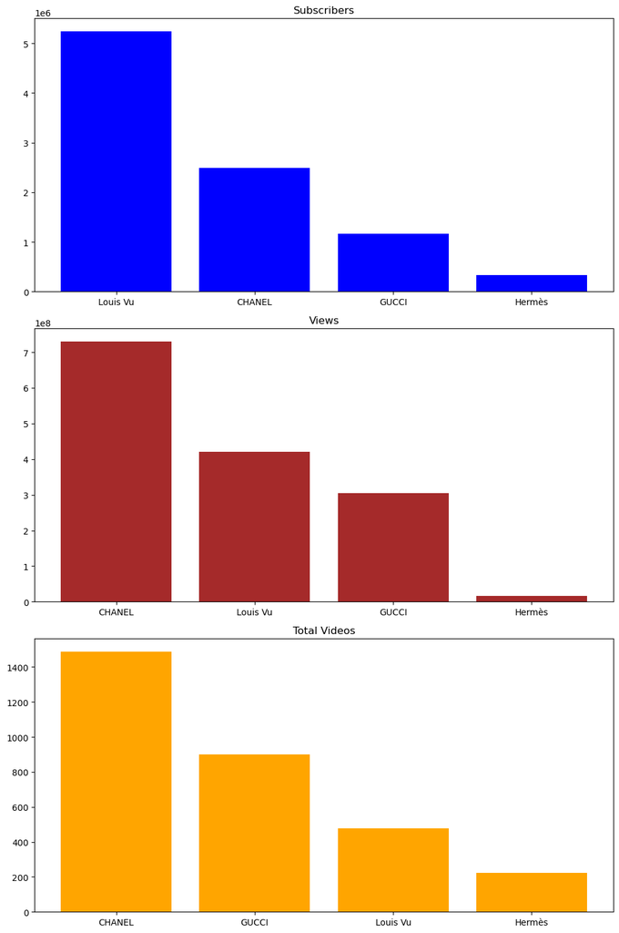

```python
import pandas as pd
import matplotlib.pyplot as plt

# Sort the DataFrame by 'Subscribers' in descending order
combined_Clothing_brands_channels_df_subscribers_sorted = combined_Clothing_brands_channels_df.sort_values(by='Subscribers', ascending=False)

# Shorten channel names
combined_Clothing_brands_channels_df_subscribers_sorted['Channel_name'] = combined_Clothing_brands_channels_df_subscribers_sorted['Channel_name'].apply(lambda x: x[:8])

# Plotting Subscribers in descending order
fig, axes = plt.subplots(nrows=3, ncols=1, figsize=(10, 15))

axes[0].bar(combined_Clothing_brands_channels_df_subscribers_sorted['Channel_name'], combined_Clothing_brands_channels_df_subscribers_sorted['Subscribers'], color='blue')
axes[0].set_title('Subscribers')

# Sort the DataFrame by 'Views' in descending order
combined_Clothing_brands_channels_df_views_sorted = combined_Clothing_brands_channels_df.sort_values(by='Views', ascending=False)

# Shorten channel names
combined_Clothing_brands_channels_df_views_sorted['Channel_name'] = combined_Clothing_brands_channels_df_views_sorted['Channel_name'].apply(lambda x: x[:8])

# Plotting Views in descending order
axes[1].bar(combined_Clothing_brands_channels_df_views_sorted['Channel_name'],combined_Clothing_brands_channels_df_views_sorted['Views'], color='brown')
axes[1].set_title('Views')

# Sort the DataFrame by 'Total_videos' in descending order
combined_Clothing_brands_channels_df_total_videos_sorted =combined_Clothing_brands_channels_df.sort_values(by='Total_videos', ascending=False)

# Shorten channel names
combined_Clothing_brands_channels_df_total_videos_sorted['Channel_name'] = combined_Clothing_brands_channels_df_total_videos_sorted['Channel_name'].apply(lambda x: x[:8])

# Plotting Total Videos in descending order
axes[2].bar(combined_Clothing_brands_channels_df_total_videos_sorted['Channel_name'], combined_Clothing_brands_channels_df_total_videos_sorted['Total_videos'], color='orange')
axes[2].set_title('Total Videos')

# Adjust layout for better visibility
plt.tight_layout()

# Show the plot
plt.show()
```